# 02 data analysis

Author

Dybcio Katarzyna, Frejter Quoc

Published

May 6, 2024

```r
packages <- c("readr","xts","tidyverse", "DT", "patchwork", "ggthemes", "tseries", "moments")

for (package in packages) {
  if (!require(package, character.only = TRUE)) {
    install.packages(package)
    library(package, character.only = TRUE)
  }
}
```

Loading data

```r
SNEUCX_train <- read_rds("input/SNEUCX_train.rds")
SNEUCX_test <- read_rds("input/SNEUCX_test.rds")

SNEUCX <- rbind(SNEUCX_train,SNEUCX_test)
```

# 1 Index returns and cumulative returns

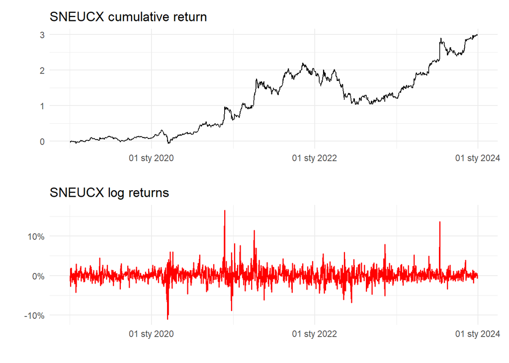

```r
p1 = ggplot(fortify(SNEUCX)) +
  geom_line(aes(x=Index, y=CumRet), colour = 'black') +
  scale_x_date(date_labels = "%d %b %Y") +
  xlab("") +
  ylab("") +
  theme(axis.title.x=element_blank(),
        axis.text.x=element_blank(),
        axis.ticks.x=element_blank()) +
  ggtitle('SNEUCX cumulative return') +
  theme_minimal()

p2 = ggplot(fortify(SNEUCX)) +
  geom_line(aes(x=Index, y=LnReturns), colour = 'red', linewidth = 0.6) +
  scale_x_date(date_labels = "%d %b %Y") +
  xlab("") +
  ylab("") +
  ggtitle('SNEUCX log returns') + scale_y_continuous(labels = scales::percent) +
  theme_minimal()

p1 / p2
```

# 2 Distribution of data

## 2.1 Histogram

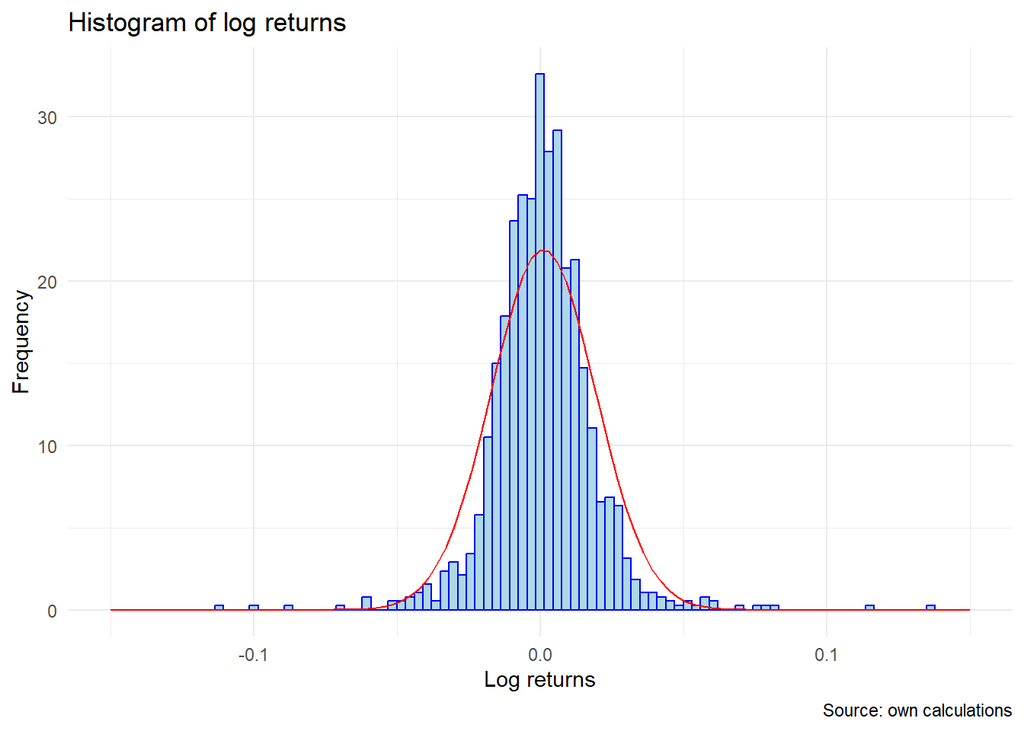

```r
tibble(r = as.numeric(SNEUCX$LnReturns)) %>%
  ggplot(aes(r)) +
  geom_histogram(aes(y =..density..),
                 colour = "blue",
                 fill = "lightblue",
                 bins = 100) +
  stat_function(fun = dnorm,
                args = list(mean = mean(SNEUCX$LnReturns),
                            sd = sd(SNEUCX$LnReturns)),
                colour = "red"
                ) +
  theme_minimal() +
  xlim(-0.15,0.15) +
  labs(
    title = "Histogram of log returns",
    y = "Frequency", x = "Log returns",
    caption = "Source: own calculations"
  )
```

## 2.2 Density

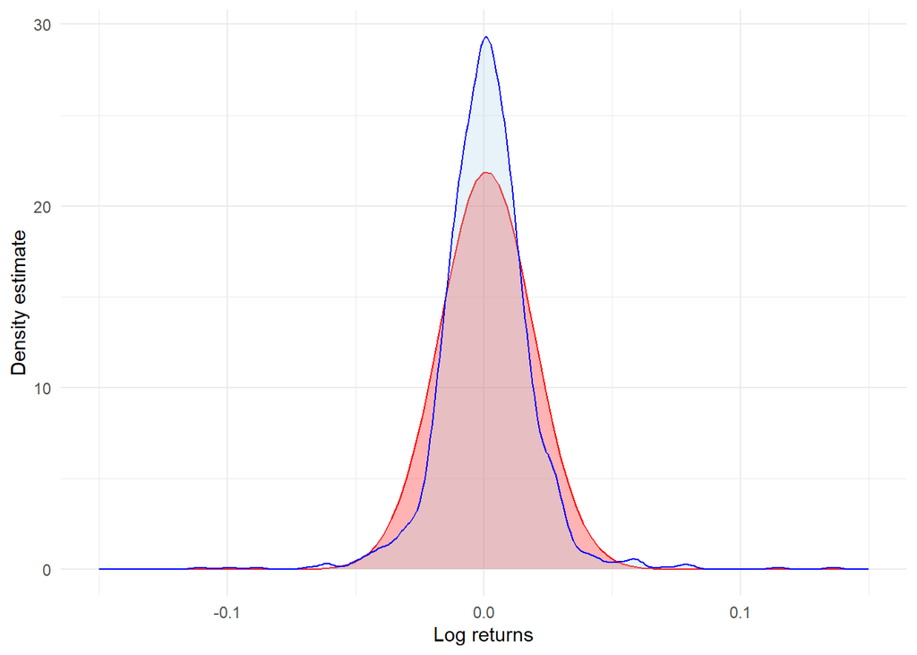

```r
ggplot(fortify(SNEUCX$LnReturns)) +
  stat_function(fun = dnorm,
                args = list(mean = mean(SNEUCX$LnReturns),
                            sd = sd(SNEUCX$LnReturns)),
                colour = "red") +
  geom_area(stat = "function", fun = dnorm, args = list(mean = mean(SNEUCX$LnReturns),
                            sd = sd(SNEUCX$LnReturns)), fill = "red", alpha = 0.3) +
  geom_density(aes(x = LnReturns), colour = 'blue', fill = "lightblue", alpha = 0.3) +
  ylab('Density estimate') +
  xlab('Log returns') +
  theme_minimal() +
  xlim(-0.15,0.15)
```

## 2.3 Interpretation

The analysis reveals that the distribution of the created index does not follow a normal distribution. The log returns are more concentrated around the average value, resulting in a higher peak at the mean. This leptokurtosis suggests a higher likelihood of outliers compared to a normal distribution. It indicates heavy tails and a greater probability of extreme returns. This observation highlights the importance of accounting for potential risks and the variability in returns when evaluating investment performance.

# 3 Quantiles

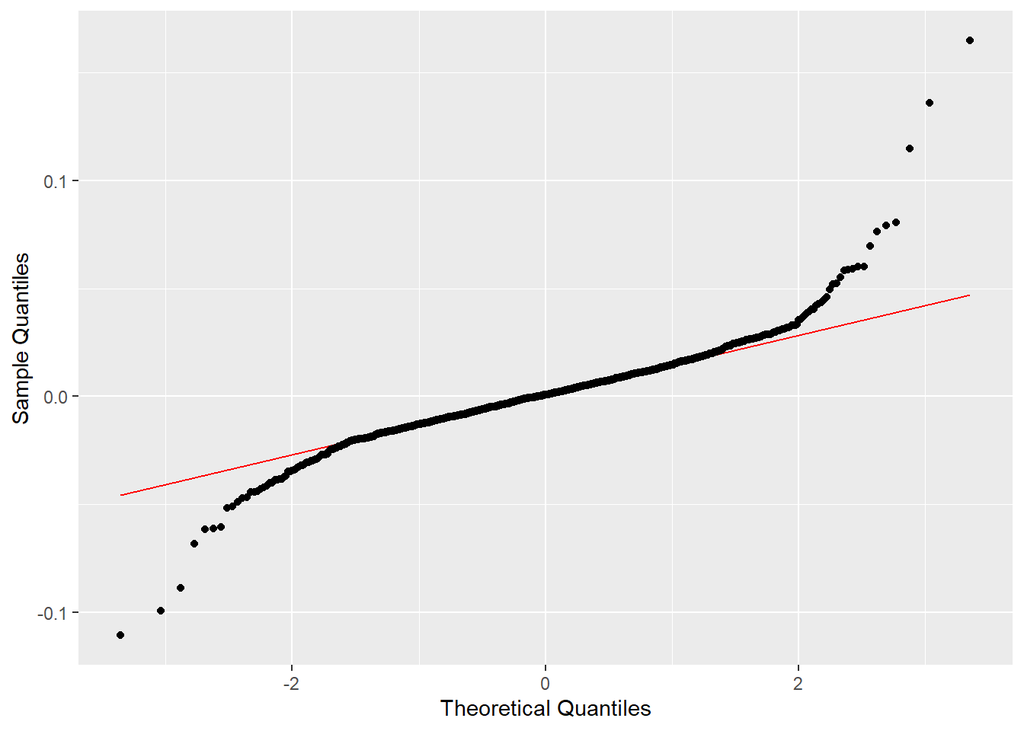

```r
ggplot(fortify(SNEUCX$LnReturns)) +
  geom_qq_line(aes(sample = LnReturns), colour = 'red') +
  geom_qq(aes(sample = LnReturns), colour = 'black') +
  ylab('Sample Quantiles') +
  xlab('Theoretical Quantiles')
```

# 4 Basic statistics

```r
ret_stats <- tibble(SNEUCX_Log_Returns = as.numeric(SNEUCX$LnReturns)) %>%
  summarise(Min = min(SNEUCX_Log_Returns),
            Quartile_1st = quantile(SNEUCX_Log_Returns,0.25),
            Median = median(SNEUCX_Log_Returns),
            Mean = mean(SNEUCX_Log_Returns),
            Quartile_3rd = quantile(SNEUCX_Log_Returns,0.75),
            Max = max(SNEUCX_Log_Returns),
            Skew = skewness(SNEUCX_Log_Returns),
            Kurtosis = kurtosis(SNEUCX_Log_Returns) - 3,
            Standard_error = sd(SNEUCX_Log_Returns)/sqrt(length(SNEUCX_Log_Returns)),
            Standard_deviation = sd(SNEUCX_Log_Returns))

tibble(Statistics = colnames(ret_stats), SNEUCX_Log_Returns = as.numeric(ret_stats)) %>%
  datatable(rownames = FALSE, options = list(dom = 't', ordering = FALSE), class = 'cell-border stripe', width = 10) %>%
  formatRound(columns = c('SNEUCX_Log_Returns'), digits = 4)
```

| Statistics | SNEUCX_Log_Returns |
| --- | --- |
| Min | -0.1107730690946288 |
| Quartile_1st | -0.008619996395397105 |
| Median | 0.0007406779716494764 |
| Mean | 0.00109557148368366 |
| Quartile_3rd | 0.01008711742673101 |
| Max | 0.1648979181049113 |
| Skew | 0.8431954715921266 |
| Kurtosis | 11.75726244855239 |
| Standard_error | 0.000513299387670149 |
| Standard_deviation | 0.01819861699574627 |

## 4.1 Interpretation

A skew of 0.8 indicates that the distribution is positively skewed, meaning it has a longer tail on the right side.

# 5 Normal distribution?

```r
jarque.bera.test(SNEUCX$LnReturns)
```

```
    Jarque Bera Test

data:  SNEUCX$LnReturns
X-squared = 7388.9, df = 2, p-value < 2.2e-16
```

## 5.1 Interpretation

In the context of the Jarque-Bera test, the null hypothesis (H0) is that the data follows a normal distribution.

Since the p-value is significantly smaller than any conventional significance level (e.g., 0.05), we reject the null hypothesis. Therefore, the distribution of SNEUCX log returns does not follow a normal distribution.